# Temperatura histórica en C.A.B.A.

Laboratorio de Datos

Ariel Salgado

20 de Julio de 2021

# Este notebook

En este notebook el objetivo es que ustedes puedan emplear lo visto en el notebook *Nociones básicas de estadística descriptiva* para caracterizar la evolución de la temperatura mensual en la C.A.B.A.

Proponemos una serie de preguntas *guía* a responder usando las herramientas que presentadas en el notebook de estadística descriptiva. Sientan la libertad de hacer nuevas preguntas y explorar el dataset libremente.

# El dataset

El dataset que usaremos puede descargarse (además del repositorio) de la página del gobierno de la ciudad en formato csv: https://data.buenosaires.gob.ar/dataset/registro-temperatura-ciudad. También lo pueden encontrar en el GitHub de la materia ya descargado.

Carguemoslo:

```r
datos = read.csv('historico_temperaturas.csv')
```

- Visualicen las primeras filas usando la función `head`

```r
head(datos)
```

|  | año | mes | máxima | mínima | media |
| --- | --- | --- | --- | --- | --- |
| 1 | 1991 | Enero | 28.4 | 19.8 | 24.10 |
| 2 | 1991 | Febrero | 27.8 | 17.8 | 22.80 |
| 3 | 1991 | Marzo | 27.6 | 18.4 | 23.00 |
| 4 | 1991 | Abril | 22.4 | 13.6 | 18.00 |
| 5 | 1991 | Mayo | 20.7 | 12.2 | 16.45 |
| 6 | 1991 | Junio | 14.8 | 7.6 | 11.20 |

Dado que mes y año no están en un formato cómodo para ser procesado y graficado, necesitamos crear un string que contenga esa misma información pero en formato *YYYY-MM-DD* (año-mes-día). Hay formas de hacerlo automáticamente, pero hoy la función la van a hacer ustedes. Les dejo un boceto:

```r
month = datos$mes
arma_fecha = function(año, mes){
  # Primero necesitamos convertir el mes en palabras a número con dos dígitos.
  # Lo hacemos con un diccionario y la función match
  mes_A_num = c('Enero'='01',
                   'Febrero'='02',
                   'Marzo'='03',
                   'Abril'='04',
                   'Mayo'='05',
                   'Junio'='06',
                   'Julio'='07',
                   'Agosto'='08',
                   'Septiembre'='09',
                   'Octubre'='10',
                   'Noviembre'='11',
                   'Diciembre'='12')
  mes_numerico = mes_A_num[ match(mes, names(mes_A_num)) ] # Exploren esto un poco en la consola para ver qué hace exactamente.
  fechas = paste(año, mes_numerico, '01', sep='-')
  #mes_numerico = mes_A_num[ mes ]
  #fechas = paste(año, mes_numerico, '01', sep='-')
  # Fijamos el día siempre en el primero del més
  fechas = as.Date(fechas) # Lo convertimos a un formato de fecha
  return(fechas)
}

datos$fecha = arma_fecha(datos$año, datos$mes)
```

# Preguntas

#### ¿Qué puede decir de la evolución de la temperatura a lo largo del tiempo?

Realice un gráfico que muestre la temperatura media en función de la fecha. *Sugerencia: agregando en* `plot(x,y)` *la opción `type='l'` obtenemos un gráfico de lineas:* `plot(x,y,type='l')`.

```r
#   año_nuevos <- function(fechas){
#   resul <- c()
#   for(f in fechas){
#     if(grepl("-01-01", toString(f))){
#       resul <- c(resul, f)
#     }
#   }
#
#   return(resul)
# }
# año_nuevos(datos$fecha)
# for(f in datos$fecha){
#   print(toString(f))
# }

#plot(datos$fecha, datos$media)
```

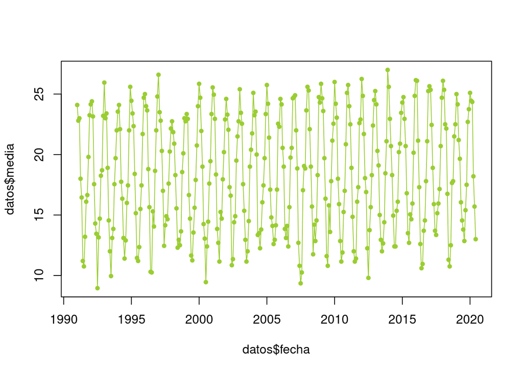

```r
#install.packages("ggplot2")
# library(ggplot2)
# ggplot(datos, aes(x=fecha, y=máxima)) + geom_line()
# plot(datos$fecha, datos$máxima, type='l')
# plot(datos$fecha, datos$mínima, type='l')
# abline(v=año_nuevos(datos$fecha))

#install.packages("devtools")
#devtools::install_github("rstudio/rmarkdown")


plot(datos$fecha, datos$media, pch=20, col='yellowgreen')
lines(datos$fecha, datos$media, col='yellowgreen')
```

#### ¿Qué puede decir de la evolución de la mínima y la máxima en función del tiempo?

Realice un gráfico que muestre la evolución de las tres temperaturas (mínima, media y máxima) a la vez, con lineas y usando diferentes colores. *Los colores los indicamos usando la opción* `col` _ en la función `plot`. _Para agregar lineas usamos la función `lines`.

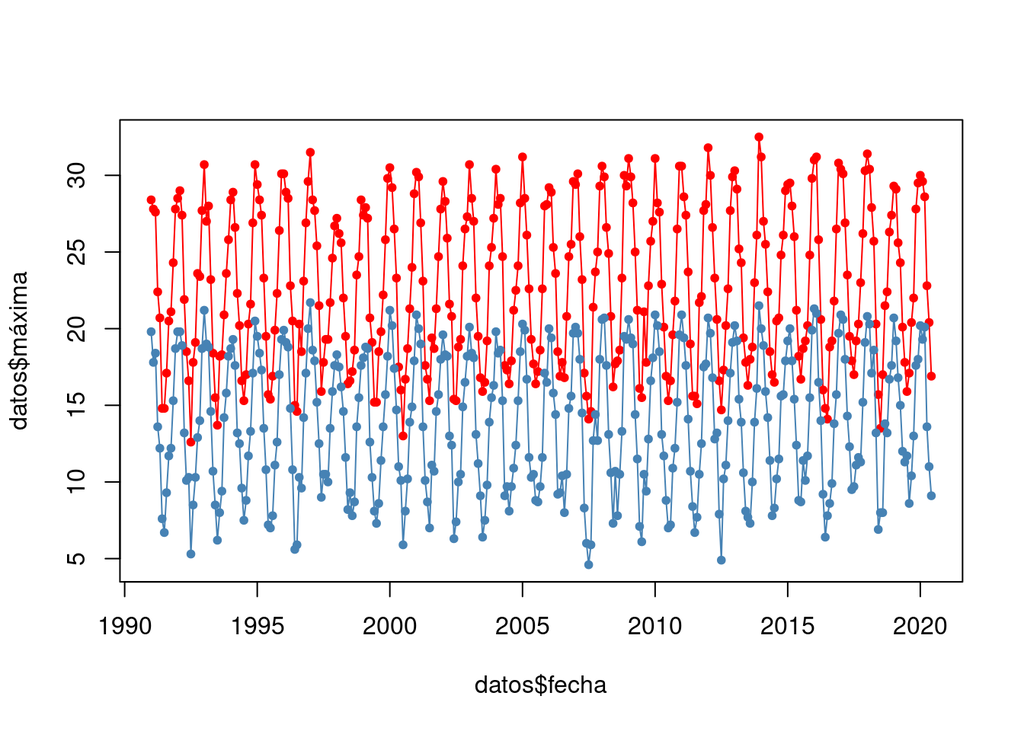

```r
plot(datos$fecha, datos$máxima, pch=20, col="red", ylim=c(min(datos$mínima), max(datos$máxima)))
lines(datos$fecha, datos$máxima, col="red")

points(datos$fecha, datos$mínima, pch=20, col="steelblue")
lines(datos$fecha, datos$mínima, col="steelblue")
```

#### ¿En qué año y mes se registró la temperatura máxima? ¿Y la mínima?

Detecte, año, mes y fecha y repita el gráfico anterior, agregando un punto rojo y uno azul en la posición de la temperatura máxima y mínima. *Para agregar puntos a un gráfico, puede usar la función* `points` *, similar a* `lines` *. Para ubicar las posiciones donde ocurre el máximo y el mínimo de un vector aproveche las funciones* `which.max` *y* `which.min`.

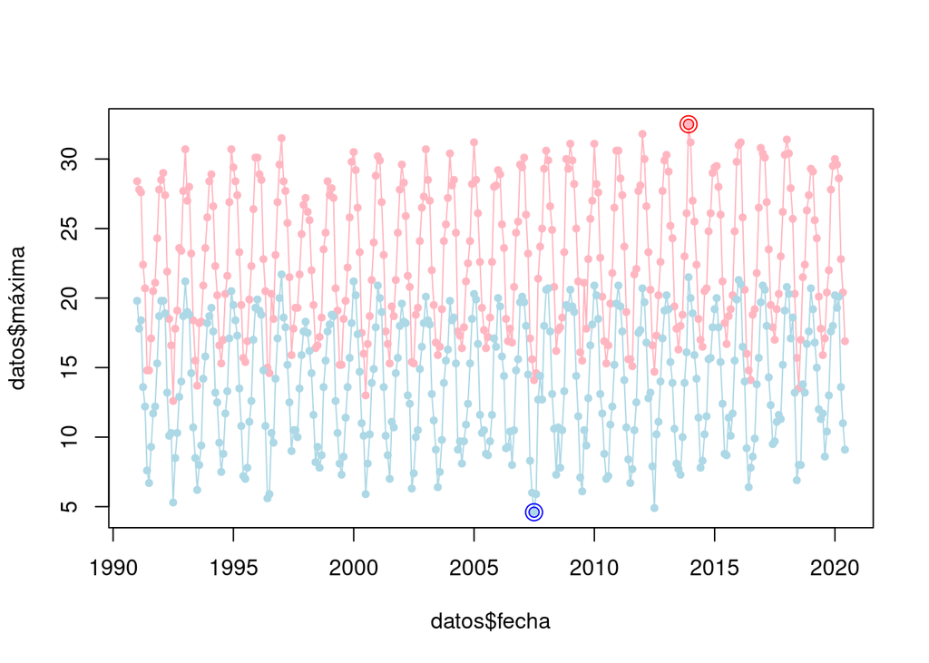

```r
plot(datos$fecha, datos$máxima, pch=20, col="lightpink", ylim=c(min(datos$mínima), max(datos$máxima)))
lines(datos$fecha, datos$máxima, col="lightpink")

points(datos$fecha, datos$mínima, pch=20, col="lightblue")
lines(datos$fecha, datos$mínima, col="lightblue")

fecha.min <- datos$fecha[ which.min(datos$mínima) ]
temp.min <- min(datos$mínima)

fecha.max <- datos$fecha[ which.max(datos$máxima) ]
temp.max <- max(datos$máxima)

points(fecha.min, temp.min, col="blue", cex=1)
points(fecha.min, temp.min, col="blue", cex=1.7)
points(fecha.max, temp.max, col="red", cex=1)
points(fecha.max, temp.max, col="red", cex=1.7)
```

```r
c(temp.min, fecha.min)
```

```
## [1]     4.6 13695.0
```

```r
c(temp.max, fecha.max)
```

```
## [1]    32.5 16040.0
```

#### ¿En torno a que valor ronda la temperatura en C.A.B.A.?

Calcule las temperaturas promedio y mediana a lo largo de todos los años usando la temperatura media mensual. ¿Son similares en este caso? Calcule la desviación estandar de la temperatura media y los cuartiles 1ro y 3ro, y agreguelos al gráfico original de la temperatura media. *La función* `abline` *permite dibujar lineas horizontales a través de su argumento* `h`.

```r
print("Media:")
```

```
## [1] "Media:"
```

```r
media <- mean(datos$media)
media
```

```
## [1] 18.40493
```

```r
print("Mediana:")
```

```
## [1] "Mediana:"
```

```r
mediana <- median(datos$media)
mediana
```

```
## [1] 18.275
```

```r
print("Stdv:")
```

```
## [1] "Stdv:"
```

```r
stdv <- sd(datos$media)
stdv
```

```
## [1] 4.776078
```

```r
print("Quartiles:")
```

```
## [1] "Quartiles:"
```

```r
quartiles <- quantile(datos$media, c(0.25, 0.75))
quartiles
```

```
##     25%     75%
## 14.2125 22.9000
```

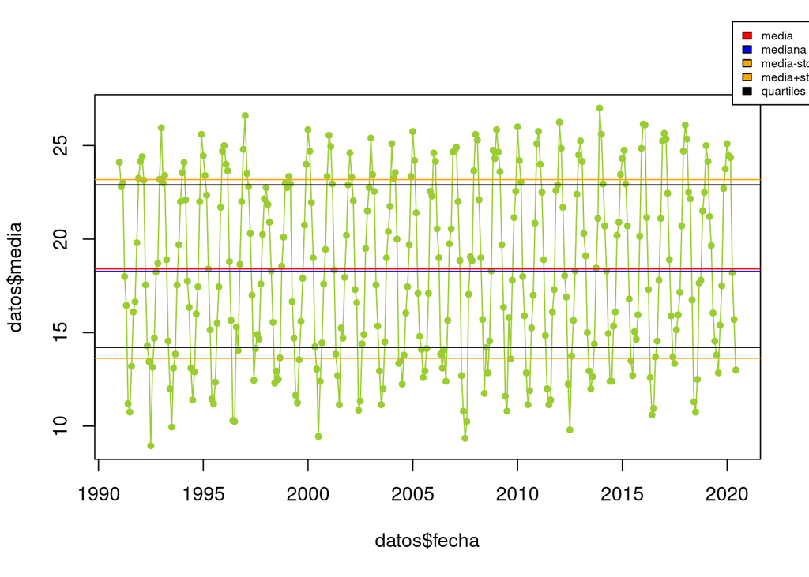

```r
plot(datos$fecha, datos$media, pch=20, col='yellowgreen')
lines(datos$fecha, datos$media, col='yellowgreen')
abline(h=c(media, mediana, media-stdv, media+stdv, quartiles), col=c('red', 'blue', 'orange', 'orange', 'black', 'black'))

legend("topright", inset=c(-0.1, -0.2), xpd=TRUE, legend=c("media", "mediana", "media-stdv", "media+stdv", "quartiles"), fill=c('red', 'blue', 'orange', 'orange', 'black', 'black'), cex=0.6)
```

#### ¿Cuál es el mes más frio del año? ¿Y el más cálido?

Calcule la temperatura media, mínima y máxima promedio para cada mes, y construya un barplot de la temperatura media separado por mes. ¿Qué meses presentan temperaturas más atípicas?

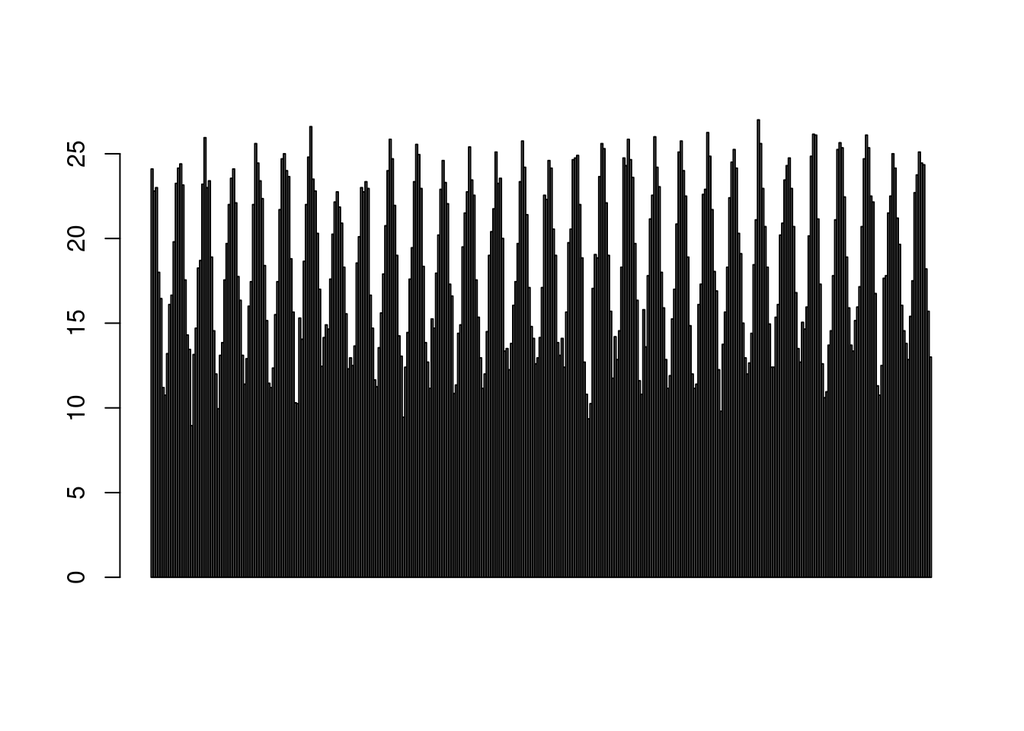

```r
barplot(datos$media)
```

```r
# Preguntar sobre cómo filtrar por mes cuando la data es tipo Date
```

#### ¿Cuál es el mes con temperatura más variable?

Calcule la variabilidad de la temperatura de cada mes como `máxima-mínima` (llamada *amplitud térmica*) y calcule el promedio mensual y construya un boxplot para cada mes. ¿En qué mes es más variable la temperatura? ¿Y en cuál menos? ¿Observa una relación con la temperatura del mes?

#### ¿Cómo se relacionan la temperatura media y la variabilidad?

Grafique la temperatura media contra la variabilidad. ¿Observa una relación? Calcule el coeficiente de correlación entre ambas. ¿Se condice con lo que observa en el gráfico?

> **Correlación**: Covarianza a-dimensional

> $$\text{COR} (X,Y) = \frac { \text{COV} (X,Y) } {\sqrt{ (V_x, V_y)}}$$

```r
# Que es la variablidada?
var(datos$media)
```

```
## [1] 22.81092
```

```r
cor(datos$media, datos$media)
```

```
## [1] 1
```

#### ¿Cómo cambió la temperatura a lo largo de los años?

Grafique boxplots separando la temperatura media por año, y la amplitud térmica por año. Calcule la temperatura media, mínima y máxima por año. ¿Detecta algún año especialmente frío? Grafique la temperatura media, máxima y mínima año a año. ¿Puede detectar un cambio a lo largo de los años?